# Homework 5

Annanina Koster

4 november 2015

Read the chapter 2.4 from ,,Analiza danych z programem R, Modele liniowe mieszane’’ or in English (https://www.ma.utexas.edu/users/mks/384E07/nestedfactors.pdf + how to do this in R http://www.stat.wisc.edu/courses/st333-larget/chimps.pdf).

Now, imagine following scenario.

You have data for n patients. For each patient you have his/her blood pressure, gender and type of diabetes (here, let’s assume that there are three types of diabetes: pre, 1 and 2). Let assume that male have blood pressure is higher than female (on average) and the difference is delta1 = 1. Then let’s assume that nested effect of diabetes is delta2= (0, 0, 0.5) for male and delta3=(0, 0, 1) for female.

Our goal is to find sample size, for which the test for nested effect (only effect of diabetes) has power 0.8.

Create a simulation study in which for a given n - sample size you will calculate power for hypothesis H0: delta2=0 and delta3=0. Choose the smallest n for which power is not smaller than 0.8. I.e. what is the minimal number of patients that allow to detect effect of the size (0,0,0.5,0,0,1) with probability larger than 80%.

A function has been made which creates the data as described above and fits the model to it.

```r
set.seed(124)

#n <- 450 #nr of patients
m <- 1000 #nr of replicates

data <- function(n){

x <- rep(c("pre", 1, 2), n)
diab.type <- sample(x,n)

y <- rep(c("male", "female"), n)
gender <- sample(y,n)
nr.female <- table(gender)[[1]]
nr.male <- table(gender)[[2]]
  blood.female <- rnorm(nr.female, 0, 1)
  blood.male <- rnorm(nr.male, 1,1)
blood <- 0
gender <- sort(gender)
  for(i in 1:nr.female){
    blood[i] <- blood.female[i]
  }
  for(i in (nr.female+1):n){
    blood[i] <- blood.male[i-nr.female]
  }

for(i in 1:n){
  if(diab.type[i]=="2" & gender[i]=="male"){
    blood[i] <- blood[i]+0.5
    if(diab.type[i]=="2" & gender[i]=="female"){
      blood[i] <- blood[i]+1
    }
  }
}

model.diab <- lm(blood~gender/diab.type)
anova(model.diab)[2,5]

}
```

Another function is created, which makes the model m=1000 times and calculates the power of the test and plots this result.

```r
power.func <- function(n){

pvals <- replicate(m, data(n))

count.pvals <- 0
for(i in 1:m){
  if(pvals[i]<0.05){count.pvals <- count.pvals+1}
}
power.pvals <- count.pvals/m
power.pvals

#n <- 400: <.80
#n <- 500 & 450: >0.8

library(ggplot2)

df <- data.frame(p=pvals)

    ggplot(df, aes(x=p)) +
      geom_histogram() +
      xlim(0,1) +
      ggtitle(paste0(round(100*mean(pvals < 0.05),1), "% of p-values smaller than 0.05 \n\n",
                     round(100*mean(pvals >= 0.05),1), "% of p-values larger than 0.05"))

}
```

```r
set.seed(124)
power.func(1000) #almost 1
```

```
## stat_bin: binwidth defaulted to range/30. Use 'binwidth = x' to adjust this.
```

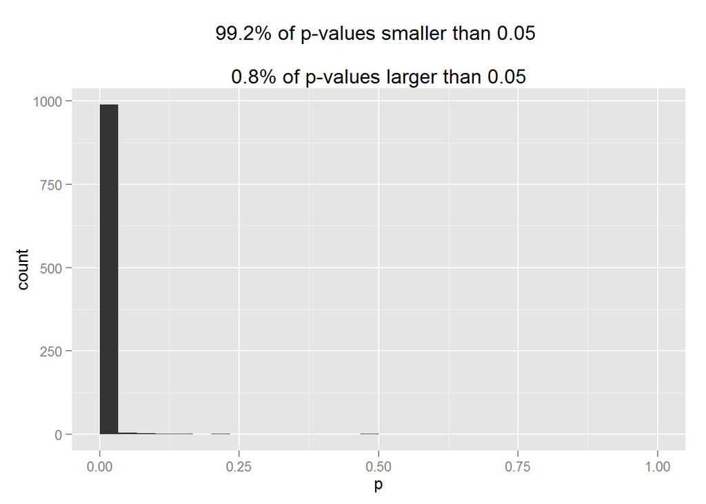

```r
set.seed(124)
power.func(100) #very small
```

```
## stat_bin: binwidth defaulted to range/30. Use 'binwidth = x' to adjust this.
```

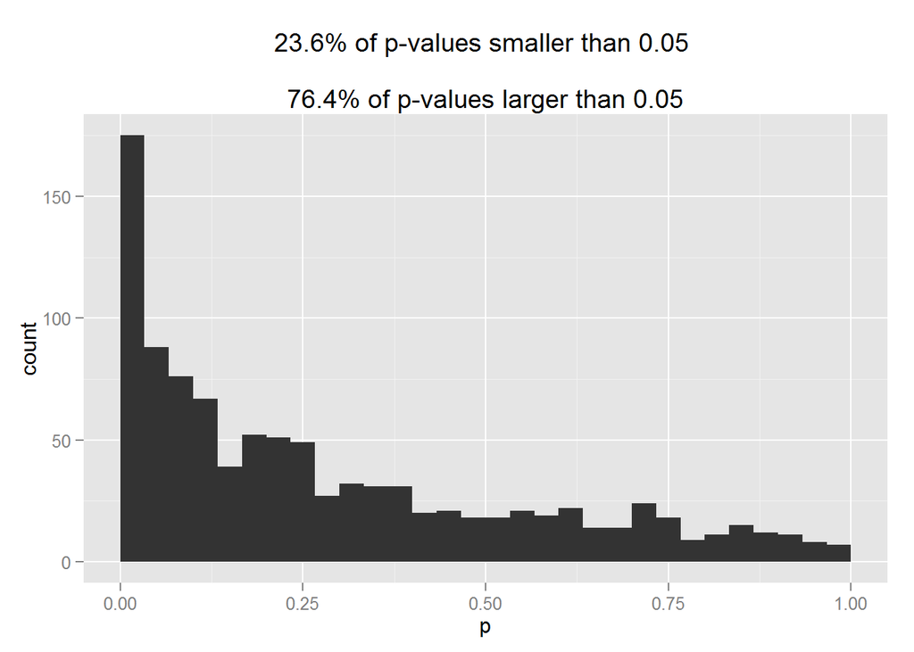

```r
set.seed(124)
power.func(500) #around 0.8 (larger)
```

```
## stat_bin: binwidth defaulted to range/30. Use 'binwidth = x' to adjust this.
```

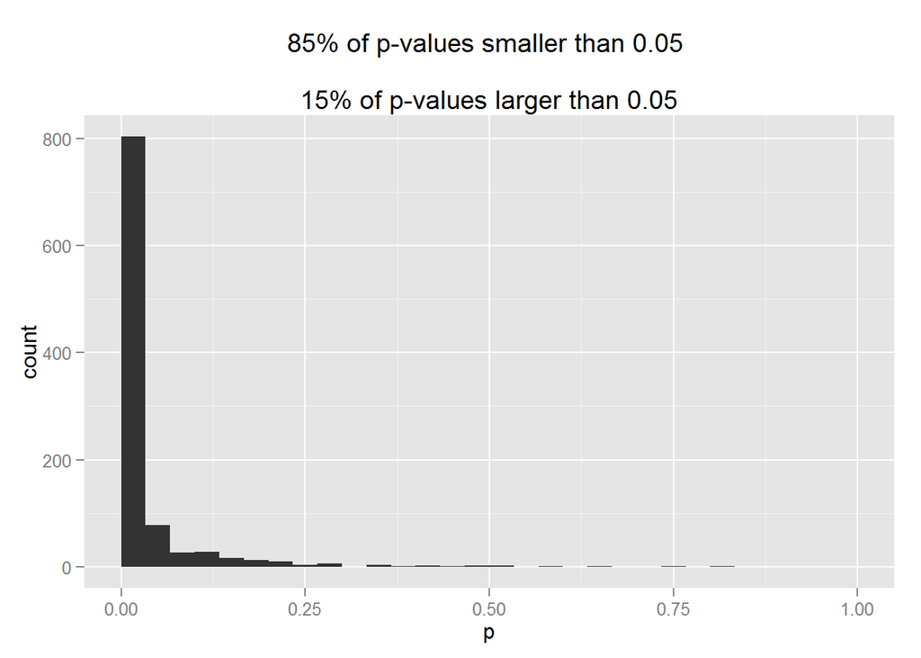

```r
set.seed(124)
power.func(400) #around 0.8 (smaller)
```

```
## stat_bin: binwidth defaulted to range/30. Use 'binwidth = x' to adjust this.
```

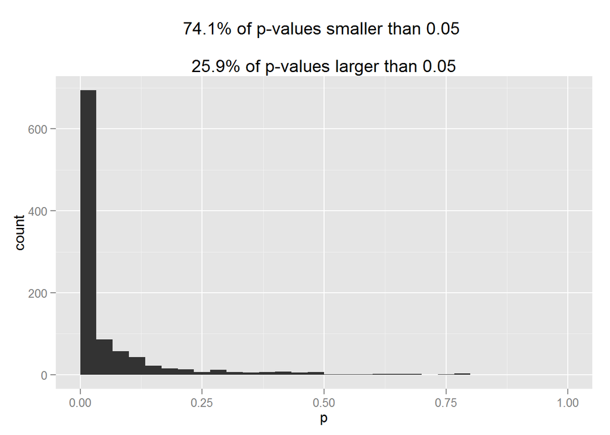

```r
set.seed(124)
power.func(430) #0.801 (lucky guess!)
```

```
## stat_bin: binwidth defaulted to range/30. Use 'binwidth = x' to adjust this.
```

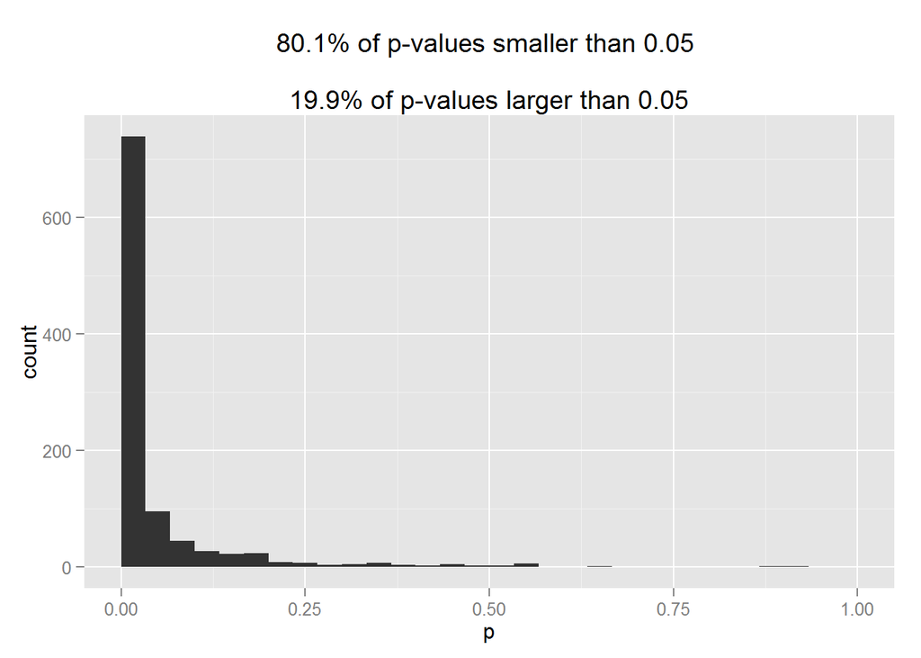

```r
set.seed(124)
power.func(429) #0.778
```

```
## stat_bin: binwidth defaulted to range/30. Use 'binwidth = x' to adjust this.
```

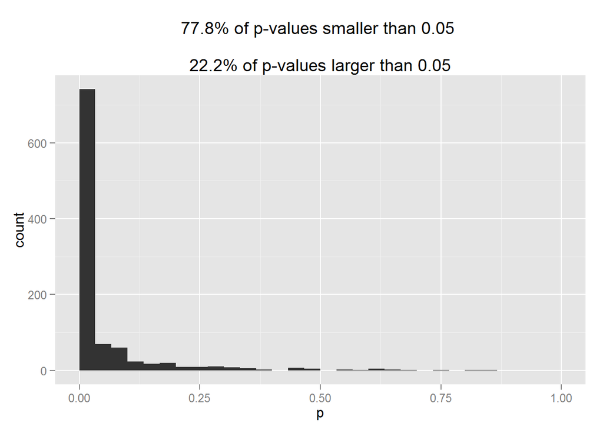